# ML & Hypothesis Tests

Here is the completed data set:

```r
mydat = read.csv("~/Desktop/data_out.csv")%>%
  filter(threshold == 250 & winds == 2)%>%
  select(-winds, - threshold, -index)
mydat%>%
  filter(complete.cases(.))%>%
  summary()
```

```
       ID                         when                     Event
 Min.   :201.0   2017-08-31 20:52:42:  2   2017-08-31 20:52:42:  2
 1st Qu.:215.0   2017-09-09 23:33:52:  2   2017-09-09 23:33:52:  2
 Median :219.0   2017-09-27 20:55:42:  2   2017-09-27 20:55:42:  2
 Mean   :217.4   2017-11-23 23:48:52:  2   2017-11-23 23:48:52:  2
 3rd Qu.:222.0   2017-01-19 19:42:22:  1   2017-01-19 19:42:22:  1
 Max.   :228.0   2017-01-21 01:58:09:  1   2017-01-21 01:58:09:  1
                 (Other)            :132   (Other)            :132
     Stress            Y            SDNN            SDANN
 Min.   :1.000   Control:123   Min.   : 24.72   Min.   :  0.6012
 1st Qu.:2.000   Episode: 19   1st Qu.: 40.48   1st Qu.:  6.8446
 Median :2.000                 Median : 49.09   Median : 11.2996
 Mean   :2.549                 Mean   : 53.14   Mean   : 15.2656
 3rd Qu.:3.000                 3rd Qu.: 57.55   3rd Qu.: 19.3051
 Max.   :5.000                 Max.   :130.25   Max.   :141.0248

    SDNNIDX          pNN50             SDSD            rMSSD
 Min.   :23.91   Min.   : 2.003   Min.   : 22.91   Min.   : 22.90
 1st Qu.:34.01   1st Qu.:12.428   1st Qu.: 38.97   1st Qu.: 38.95
 Median :43.03   Median :19.209   Median : 47.99   Median : 47.97
 Mean   :44.01   Mean   :19.934   Mean   : 48.66   Mean   : 48.64
 3rd Qu.:49.55   3rd Qu.:26.197   3rd Qu.: 56.11   3rd Qu.: 56.08
 Max.   :86.52   Max.   :67.879   Max.   :113.96   Max.   :113.92

      IRRR            MADRR            TINN             HRVi
 Min.   : 31.25   Min.   :15.63   Min.   : 62.34   Min.   : 3.990
 1st Qu.: 46.88   1st Qu.:15.63   1st Qu.: 90.20   1st Qu.: 5.773
 Median : 62.50   Median :31.25   Median :105.40   Median : 6.745
 Mean   : 65.36   Mean   :26.41   Mean   :112.25   Mean   : 7.184
 3rd Qu.: 62.50   3rd Qu.:31.25   3rd Qu.:129.03   3rd Qu.: 8.258
 Max.   :203.13   Max.   :93.75   Max.   :215.79   Max.   :13.811
```

# What is the distribution of stress for the usable surveys?

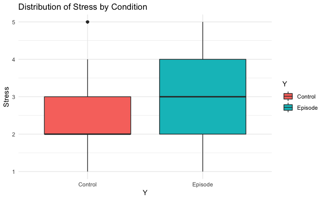

Episodes may have higher stress levels than controls. We will remove the stressed out outliers for analysis. We will also do within participant z-score centering, like so:

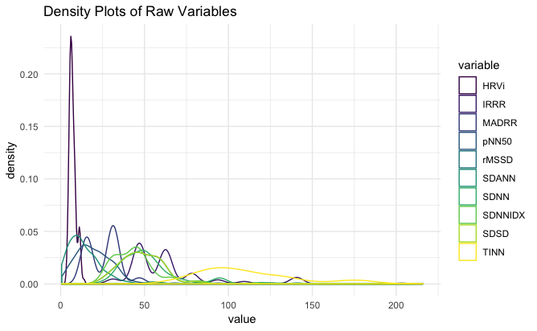

```r
mydat%>%
  filter(complete.cases(.))%>%
  filter(!(Stress > 4 & Y == "Control"))%>%
  select(ID, Y:HRVi)%>%
  # group_by(ID)%>%
  # mutate_at(.vars = vars(SDNN:HRVi), funs(scale))%>%
  # ungroup()%>%
  filter(complete.cases(.))%>%
  gather("variable", "value", SDNN:HRVi)%>%
  ggplot(aes(value, color = variable))+
  geom_density(alpha = 0.5)+
  theme_minimal()+
  scale_color_viridis(discrete = TRUE)+
  labs(title = "Density Plots of Raw Variables")
```

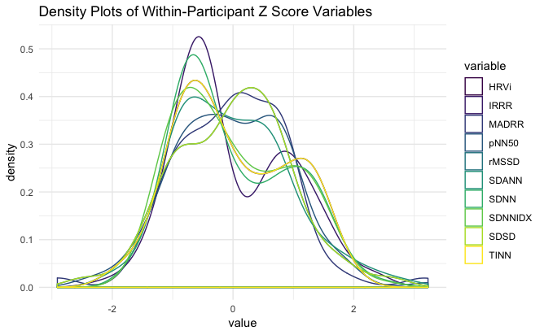

```r
mydat%>%
  filter(complete.cases(.))%>%
  filter(!(Stress > 4 & Y == "Control"))%>%
  select(ID, Y:HRVi)%>%
  group_by(ID)%>%
  mutate_at(.vars = vars(SDNN:HRVi), funs(scale))%>%
  ungroup()%>%
  filter(complete.cases(.))%>%
  gather("variable", "value", SDNN:HRVi)%>%
  ggplot(aes(value, color = variable))+
  geom_density(alpha = 0.5)+
  theme_minimal()+
  scale_color_viridis(discrete = TRUE)+
  labs(title = "Density Plots of Within-Participant Z Score Variables")
```

# Do features differ statistically by group?

What are the mean values for each of the variables by condition?

```r
mydat%>%
  filter(complete.cases(.))%>%
  filter(!(Stress > 4 & Y == "Control"))%>% #filter high stress
  select(ID, Y:HRVi)%>%
  group_by(ID)%>%
  mutate_at(.vars = vars(SDNN:HRVi), funs(scale))%>% #z score transform
  ungroup()%>%
  filter(complete.cases(.))%>%
  select(Y:HRVi)%>%
  group_by(Y)%>%
  summarise_at(.vars = vars(SDNN:HRVi), funs(mean(.)))
```

| Y | SDNN | SDANN | SDNNIDX | pNN50 | SDSD | rMSSD | IRRR | MADRR | TINN | HRVi |
| --- | --- | --- | --- | --- | --- | --- | --- | --- | --- | --- |
| Control | -0.01995289 | 0.00839158 | -0.04696531 | -0.0003382092 | 0.01154354 | 0.01154672 | -0.0376267 | 0.001773003 | -0.04322148 | -0.04322148 |
| Episode | 0.11236629 | -0.04725785 | 0.26448883 | 0.0019046516 | -0.06500836 | -0.06502626 | 0.2118977 | -0.009984806 | 0.24340519 | 0.24340519 |

Note that we now have 126 usable cases as the Z-scoring process removed participants with 1 survey or with uniform values for all their surveys.

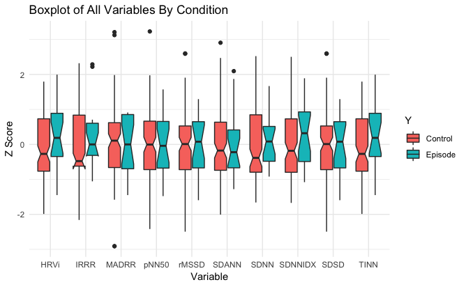

```r
mydat%>%
  filter(complete.cases(.))%>%
  filter(!(Stress > 4 & Y == "Control"))%>% #filter high stress
  select(ID, Y:HRVi)%>%
  group_by(ID)%>%
  mutate_at(.vars = vars(SDNN:HRVi), funs(scale))%>% #z score transform
  ungroup()%>%
  filter(complete.cases(.))%>%
  select(Y:HRVi)%>%
  gather("Variable", "Value", 2:11)%>%
  ggplot(aes(x=Variable, y=Value))+
  geom_boxplot(aes(fill=Y), notch = T)+
  theme_minimal()+
  labs(y = "Z Score", title = "Boxplot of All Variables By Condition")
```

```r
NA
```

Are there differences using a regular T-Test? The table below shows $p$-values at each variable’s comparison:

```r
mydat%>%
  filter(complete.cases(.))%>%
  filter(!(Stress > 4 & Y == "Control"))%>% #filter high stress
  select(ID, Y:HRVi)%>%
  group_by(ID)%>%
  mutate_at(.vars = vars(SDNN:HRVi), funs(scale))%>% #z score transform
  ungroup()%>%
  filter(complete.cases(.))%>%
  select(Y:HRVi)%>%
  summarise_at(funs(t.test(x = .[Y == "Control"],
                           y = .[Y != "Control"])$p.value),
               .vars = vars(SDNN:HRVi))
```

| SDNN | SDANN | SDNNIDX | pNN50 | SDSD | rMSSD | IRRR | MADRR | TINN | HRVi |
| --- | --- | --- | --- | --- | --- | --- | --- | --- | --- |
| 0.4989254 | 0.8127643 | 0.2095735 | 0.9921406 | 0.7276959 | 0.7276155 | 0.2859083 | 0.9564277 | 0.2102175 | 0.2102175 |

Another approach using instead, the permuation T-test, gives us $p$-values too:

```r
mydat%>%
  filter(complete.cases(.))%>%
  filter(!(Stress > 4 & Y == "Control"))%>% #filter high stress
  select(ID, Y:HRVi)%>%
  group_by(ID)%>%
  mutate_at(.vars = vars(SDNN:HRVi), funs(scale))%>% #z score transform
  ungroup()%>%
  filter(complete.cases(.))%>%
  select(Y:HRVi)%>%
  summarise_at(funs(twotPermutation(.[Y == "Control"],
                                    .[Y != "Control"],
                                    plotit = F)),
               .vars = vars(SDNN:HRVi))
```

| SDNN | SDANN | SDNNIDX | pNN50 | SDSD | rMSSD | IRRR | MADRR | TINN | HRVi |
| --- | --- | --- | --- | --- | --- | --- | --- | --- | --- |
| 0.577 | 0.821 | 0.18 | 0.994 | 0.756 | 0.751 | 0.288 | 0.96 | 0.218 | 0.23 |

It seems like none of the variables are statistically different.

# Predicting Condition

We use simple over- and under-sampling as well as ROSE and SMOTE to deal with the class imbalance problem.

```r
set.seed(2)
mydat2 = mydat%>%
  filter(complete.cases(.))%>%
  filter(!(Stress > 4 & Y == "Control"))%>% #filter high stress
  select(ID, Y:HRVi)%>%
  group_by(ID)%>%
  mutate_at(.vars = vars(SDNN:HRVi), funs(scale))%>% #z score transform
  ungroup()%>%
  filter(complete.cases(.))%>%
  select(Y:HRVi)%>%
  rename(Class = Y)
train = createDataPartition(y = mydat2$Class, p = .7, list = FALSE)
down = downSample(select(mydat2, -Class)[train,], mydat2$Class[train])
up = upSample(select(mydat2, -Class)[train,], mydat2$Class[train])
smote = SMOTE(Class ~ ., data  = as.data.frame(mydat2[train,]))
rose = ROSE(Class ~ ., data  = mydat2[train,])$data
```

## Logistic Regression/GLM

Fitting a glm and inspecting the model fit:

|  | Sampling | Variable | Significant | Estimate | Std_Error | Z_Value | P_Value |
| --- | --- | --- | --- | --- | --- | --- | --- |
| 1 | None | (Intercept) | Significant | -0.5552724 | 0.2584999 | -2.1480568 | 0.03170924 |
| 2 | None | SDNN | Not Significant | -0.1471544 | 0.7361701 | -0.1998918 | 0.84156517 |
| 3 | None | SDANN | Not Significant | -0.4950935 | 0.3603038 | -1.3741002 | 0.16941056 |
| 4 | None | SDNNIDX | Significant | 1.9995258 | 0.7683905 | 2.6022260 | 0.00926208 |
| 5 | None | pNN50 | Significant | 3.2196423 | 1.4502038 | 2.2201310 | 0.02640988 |
| 6 | None | SDSD | Significant | 1963.8181463 | 901.5415666 | 2.1782891 | 0.02938452 |
| 7 | None | rMSSD | Significant | -1966.6913492 | 901.7576709 | -2.1809533 | 0.02918687 |
| 8 | None | IRRR | Not Significant | -1.2346495 | 0.8381585 | -1.4730503 | 0.14073748 |
| 9 | None | MADRR | Significant | -1.1511777 | 0.5820801 | -1.9776964 | 0.04796297 |
| 10 | None | TINN | Not Significant | 0.2720186 | 0.7562355 | 0.3597009 | 0.71907082 |

[output cut: 40 more lines]

Evaluating prediction:

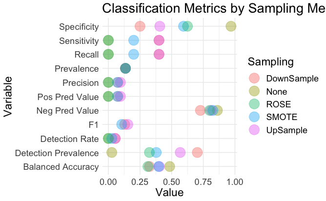

## RandomForest

```r
tc = trainControl("cv", 10, savePredictions=T)
rfFit = train(Y ~.,
               method = "rf",
               data=mydat2[train,],
               trControl = tc)
rfFit$finalModel
```

```
Call:
 randomForest(x = x, y = y, mtry = param$mtry)
               Type of random forest: classification
                     Number of trees: 500
No. of variables tried at each split: 2

        OOB estimate of  error rate: 16.67%
Confusion matrix:
        Control Episode class.error
Control      78       3  0.03703704
Episode      13       2  0.86666667
```

Evaluating prediction:

```r
pred = predict(rfFit,newdata = mydat2[-train,])%>%
  tibble(pred = ., obs = mydat2[-train,]$Y)
confusionMatrix(pred$pred, pred$obs, positive = "Episode")
```

```
Confusion Matrix and Statistics

          Reference
Prediction Control Episode
   Control      24       4
   Episode       2       0

               Accuracy : 0.8
                 95% CI : (0.6143, 0.9229)
    No Information Rate : 0.8667
    P-Value [Acc > NIR] : 0.9046

                  Kappa : -0.0976
 Mcnemar's Test P-Value : 0.6831

            Sensitivity : 0.00000
            Specificity : 0.92308
         Pos Pred Value : 0.00000
         Neg Pred Value : 0.85714
             Prevalence : 0.13333
         Detection Rate : 0.00000
   Detection Prevalence : 0.06667
      Balanced Accuracy : 0.46154

       'Positive' Class : Episode
```

## SVM

Fitting and inspecting the model:

```r
tc = trainControl("cv", 10, savePredictions=T)
svmFit = train(Y ~.,
               method = "svmLinear2",
               data=mydat2[train,],
               trControl = tc)
svmFit
```

```
Support Vector Machines with Linear Kernel

96 samples
10 predictors
 2 classes: 'Control', 'Episode'

No pre-processing
Resampling: Cross-Validated (10 fold)
Summary of sample sizes: 86, 86, 87, 87, 86, 86, ...
Resampling results across tuning parameters:

  cost  Accuracy   Kappa
  0.25  0.8455556  0
  0.50  0.8455556  0
  1.00  0.8455556  0

Accuracy was used to select the optimal model using the largest value.
The final value used for the model was cost = 0.25.
```

Evaluating prediction:

```r
pred = predict(svmFit,newdata = mydat2[-train,])%>%
  tibble(pred = ., obs = mydat2[-train,]$Y)
confusionMatrix(pred$pred, pred$obs, positive = "Episode")
```

```
Confusion Matrix and Statistics

          Reference
Prediction Control Episode
   Control      26       4
   Episode       0       0

               Accuracy : 0.8667
                 95% CI : (0.6928, 0.9624)
    No Information Rate : 0.8667
    P-Value [Acc > NIR] : 0.6292

                  Kappa : 0
 Mcnemar's Test P-Value : 0.1336

            Sensitivity : 0.0000
            Specificity : 1.0000
         Pos Pred Value :    NaN
         Neg Pred Value : 0.8667
             Prevalence : 0.1333
         Detection Rate : 0.0000
   Detection Prevalence : 0.0000
      Balanced Accuracy : 0.5000

       'Positive' Class : Episode
```

## NeuralNet

Fitting and inspecing the model:

```r
netFit
```

```
Neural Network

96 samples
10 predictors
 2 classes: 'Control', 'Episode'

No pre-processing
Resampling: Cross-Validated (10 fold)
Summary of sample sizes: 87, 86, 86, 86, 86, 87, ...
Resampling results across tuning parameters:

  size  decay  Accuracy   Kappa
  1     0e+00  0.8455556   0.00000000
  1     1e-04  0.8455556   0.00000000
  1     1e-01  0.8455556   0.00000000
  3     0e+00  0.7611111   0.08923913
  3     1e-04  0.7200000  -0.04879555
  3     1e-01  0.8155556   0.10648922
  5     0e+00  0.7622222   0.21235926
  5     1e-04  0.7411111   0.12347826
  5     1e-01  0.8044444   0.03311966

Accuracy was used to select the optimal model using the largest value.
The final values used for the model were size = 1 and decay = 0.1.
```

Evaluating prediction:

```r
pred = predict(netFit,newdata = mydat2[-train,])%>%
  tibble(pred = ., obs = mydat2[-train,]$Y)
confusionMatrix(pred$pred, pred$obs, positive = "Episode")
```

```
Confusion Matrix and Statistics

          Reference
Prediction Control Episode
   Control      26       4
   Episode       0       0

               Accuracy : 0.8667
                 95% CI : (0.6928, 0.9624)
    No Information Rate : 0.8667
    P-Value [Acc > NIR] : 0.6292

                  Kappa : 0
 Mcnemar's Test P-Value : 0.1336

            Sensitivity : 0.0000
            Specificity : 1.0000
         Pos Pred Value :    NaN
         Neg Pred Value : 0.8667
             Prevalence : 0.1333
         Detection Rate : 0.0000
   Detection Prevalence : 0.0000
      Balanced Accuracy : 0.5000

       'Positive' Class : Episode
```

# Conclusion